# Project_SocialMedia

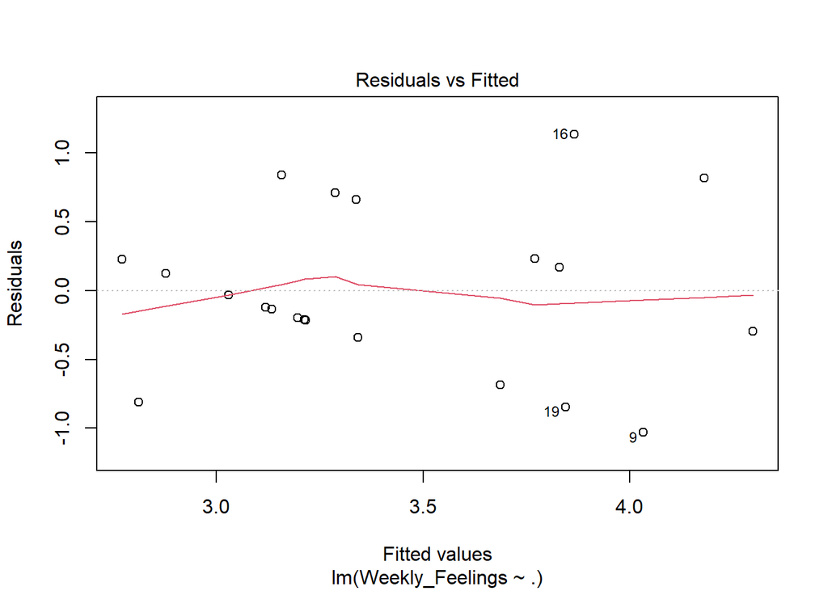

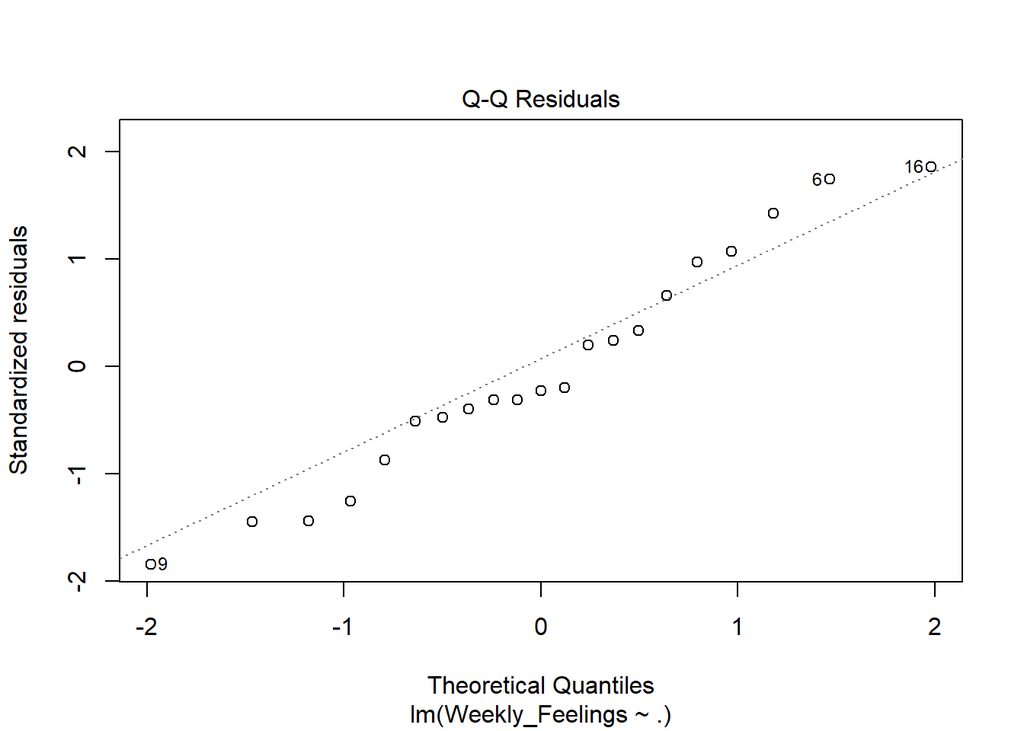

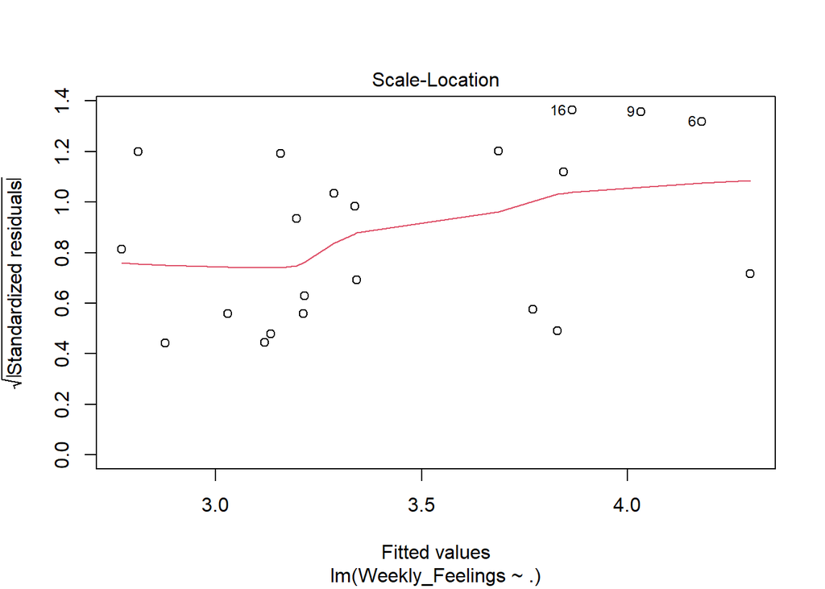

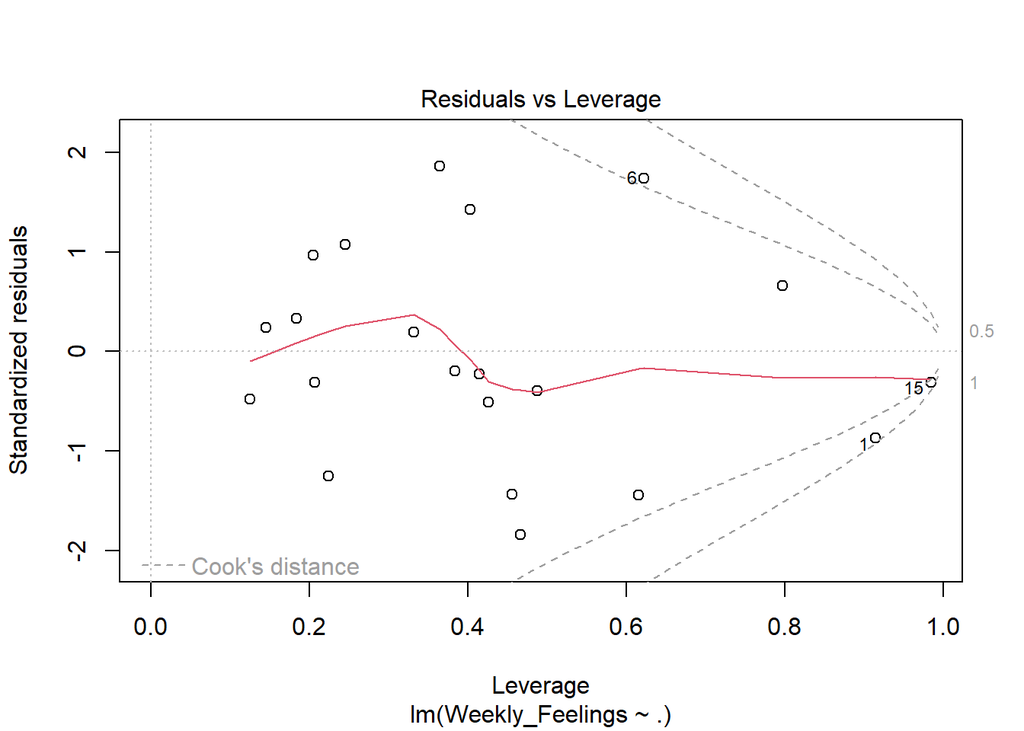

```r
# Reset plotting parameters
par(mfrow = c(1, 1))

# Diagnostic plots for the linear regression model
plot(sm_model_fit)
```

```r
# Assess the acceptance of the model
# Check R-squared and adjusted R-squared
r_squared <- summary(sm_model_fit)$r.squared
adj_r_squared <- summary(sm_model_fit)$adj.r.squared
cat("R-squared:", r_squared, "\n")
```

```
## R-squared: 0.3681669
```

```r
cat("Adjusted R-squared:", adj_r_squared, "\n")
```

```
## Adjusted R-squared: -0.05305517
```

```r
# Check the F-statistic and its p-value
f_statistic <- summary(sm_model_fit)$fstatistic
f_statistic_value <- f_statistic[1]
f_statistic_p_value <- pf(f_statistic_value, f_statistic[2], f_statistic[3], lower.tail = FALSE)
cat("F-statistic:", f_statistic_value, "\n")
```

```
## F-statistic: 0.8740447
```

```r
cat("p-value:", f_statistic_p_value, "\n")
```

```
## p-value: 0.5630702
```

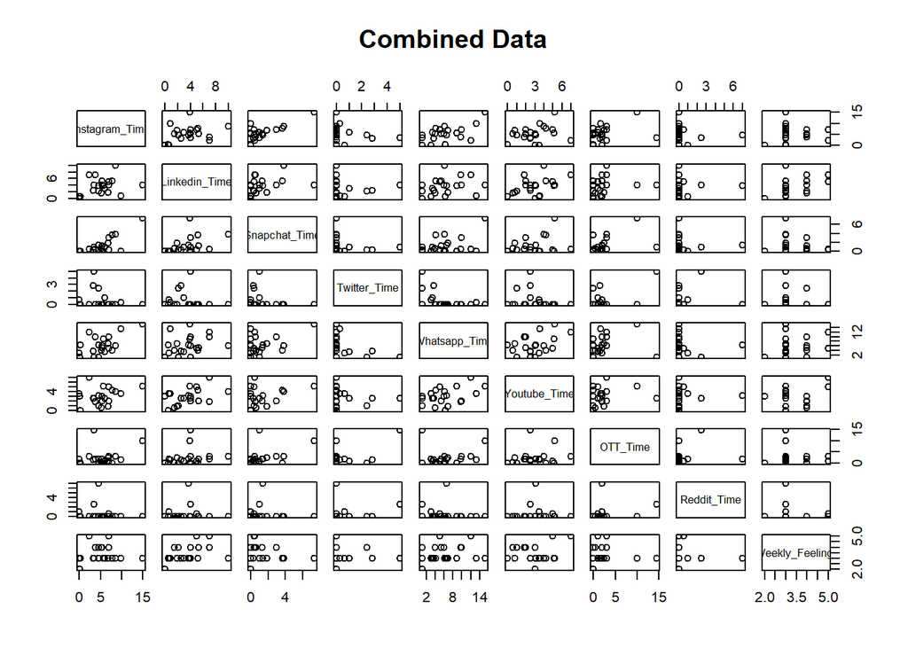

```r
# Plot pairs
pairs(combined_data, main = "Combined Data")
```

```r
confint(sm_model_fit,level=0.95)
```

```
##                      2.5 %    97.5 %
## (Intercept)     1.70641678 4.0234160
## Instagram_Time -0.14970258 0.2352856
## Linkedin_Time  -0.01267794 0.3436768
## Snapchat_Time  -0.65223144 0.1496165
## Twitter_Time   -0.63585058 0.5122586
## Whatsapp_Time  -0.13013201 0.1835051
## Youtube_Time   -0.28777142 0.2298811
## OTT_Time       -0.19290127 0.2307049
## Reddit_Time    -0.30972003 0.1904697
```

```r
fitted(sm_model_fit)
```

```
##        1        2        3        4        5        6        7        8
## 3.195734 3.119407 4.297236 3.769835 2.877191 4.180310 3.829846 3.338213
##        9       10       11       12       13       14       15       16
## 4.031759 2.811899 3.157799 3.216286 3.287846 3.342778 3.030121 3.865039
##       17       18       19       20       21
## 3.686005 3.212938 3.844495 2.771599 3.133664
```

```r
residuals(sm_model_fit)
```

```
##           1           2           3           4           5           6
## -0.19573375 -0.11940697 -0.29723590  0.23016512  0.12280947  0.81968953
##           7           8           9          10          11          12
##  0.17015430  0.66178713 -1.03175882 -0.81189945  0.84220088 -0.21628599
##          13          14          15          16          17          18
##  0.71215357 -0.34277817 -0.03012096  1.13496119 -0.68600454 -0.21293846
##          19          20          21
## -0.84449530  0.22840137 -0.13366425
```

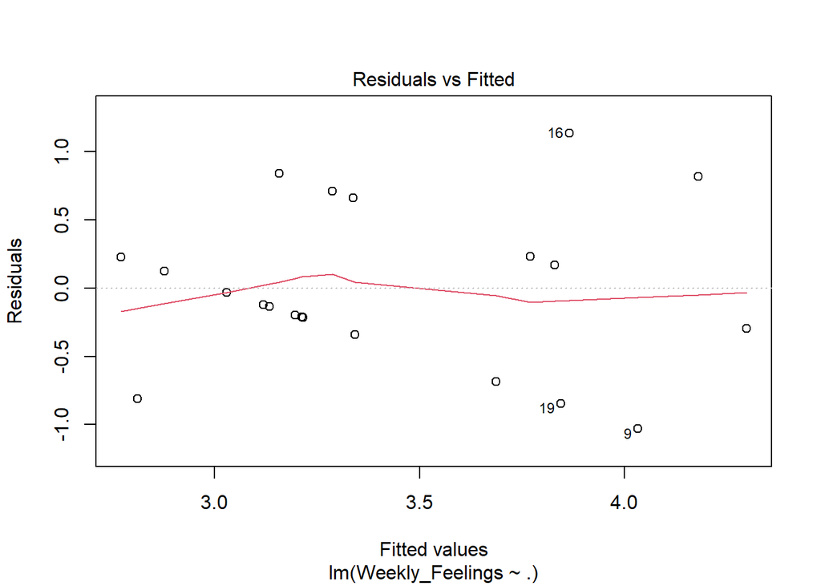

```r
# Plot residuals vs. fitted values
plot(sm_model_fit, which = 1)
```

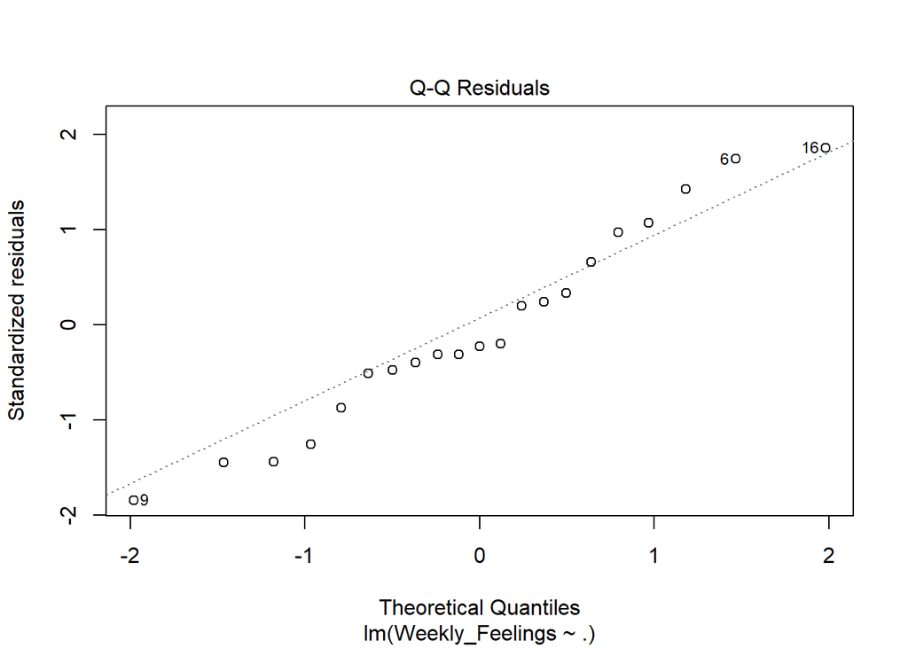

```r
# Plot normal Q-Q plot of residuals
plot(sm_model_fit, which = 2)
```

```r
# Make predictions
predictions <- predict(sm_model_fit, newdata = combined_data)

# Print predictions
print(predictions)
```

```
##        1        2        3        4        5        6        7        8
## 3.195734 3.119407 4.297236 3.769835 2.877191 4.180310 3.829846 3.338213
##        9       10       11       12       13       14       15       16
## 4.031759 2.811899 3.157799 3.216286 3.287846 3.342778 3.030121 3.865039
##       17       18       19       20       21
## 3.686005 3.212938 3.844495 2.771599 3.133664
```

```r
# Calculate Mean Squared Error (MSE)
mse <- mean(sm_model_fit$residuals^2)

# Calculate Root Mean Squared Error (RMSE)
rmse <- sqrt(mse)

# Calculate Mean Absolute Error (MAE)
mae <- mean(abs(sm_model_fit$residuals))

# Print the accuracy metrics
cat("Mean Squared Error (MSE):", mse, "\n")
```

```
## Mean Squared Error (MSE): 0.3352584
```

```r
cat("Root Mean Squared Error (RMSE):", rmse, "\n")
```

```
## Root Mean Squared Error (RMSE): 0.579015
```

```r
cat("Mean Absolute Error (MAE):", mae, "\n")
```

```
## Mean Absolute Error (MAE): 0.4687926
```

The model’s R-squared value is 0.3682, indicating that approximately 36.82% of the variance in the dependent variable (Weekly Feelings) is explained by the independent variables in the model.

However, the adjusted R-squared value is negative (-0.05306), suggesting that the model may not be adequately capturing the underlying relationships in the data, especially when considering the number of predictors in the model.

Only the coefficient for the intercept is statistically significant at the 0.05 level, with a p-value of 0.000163.

2. Logistic Regression:

```r
# Create a binary outcome variable
combined_data$Feelings_Category <- ifelse(combined_data$Weekly_Feelings > 3, "High", "Low")

# Convert Feelings_Category to factor
combined_data$Feelings_Category <- factor(combined_data$Feelings_Category, levels = c("Low", "High"))

# Drop Weekly_Feelings variable using subset function
combined_data <- subset(combined_data, select = -Weekly_Feelings)

# Check the structure of the dataset
str(combined_data)
```

```
## 'data.frame':    21 obs. of  9 variables:
##  $ Instagram_Time   : num  3.5 7.73 3.77 5.38 0 ...
##  $ Linkedin_Time    : num  4 5.2 7 5.317 0.583 ...
##  $ Snapchat_Time    : num  1 3.683 0.533 1.3 0 ...
##  $ Twitter_Time     : num  5 0 0 0 0.667 ...
##  $ Whatsapp_Time    : num  1 4.18 9.83 5.3 3 ...
##  $ Youtube_Time     : num  2.5 4.25 1.85 2 3.5 7 3 2 4 3 ...
##  $ OTT_Time         : num  14.5 0 2 2 2 3 0 3 3 0 ...
##  $ Reddit_Time      : num  2.5 0 0 0 1 0 0 0 0 0 ...
##  $ Feelings_Category: Factor w/ 2 levels "Low","High": 1 1 2 2 1 2 2 2 1 1 ...
```

```r
# Fit logistic regression model
logistic_model <- glm(Feelings_Category ~ ., data = combined_data, family = binomial)

# Summary of the model
summary(logistic_model)
```

```
##
## Call:
## glm(formula = Feelings_Category ~ ., family = binomial, data = combined_data)
##
## Coefficients:
##                Estimate Std. Error z value Pr(>|z|)
## (Intercept)    -0.37728    2.15508  -0.175   0.8610
## Instagram_Time  0.14075    0.28324   0.497   0.6192
## Linkedin_Time   0.94964    0.56173   1.691   0.0909 .
## Snapchat_Time  -1.67460    1.16163  -1.442   0.1494
## Twitter_Time   -0.42712    0.86589  -0.493   0.6218
## Whatsapp_Time   0.01712    0.30092   0.057   0.9546
## Youtube_Time   -0.84042    0.65118  -1.291   0.1968
## OTT_Time        0.06294    0.53863   0.117   0.9070
## Reddit_Time    -0.64305    1.97247  -0.326   0.7444
## ---
## Signif. codes:  0 '***' 0.001 '**' 0.01 '*' 0.05 '.' 0.1 ' ' 1
##
## (Dispersion parameter for binomial family taken to be 1)
##
##     Null deviance: 27.910  on 20  degrees of freedom
## Residual deviance: 17.929  on 12  degrees of freedom
## AIC: 35.929
##
## Number of Fisher Scoring iterations: 7
```

```r
# Check p-values
p_values <- summary(logistic_model)$coefficients[, 4]
print(p_values)
```

```
##    (Intercept) Instagram_Time  Linkedin_Time  Snapchat_Time   Twitter_Time
##     0.86102839     0.61923153     0.09092251     0.14941627     0.62181540
##  Whatsapp_Time   Youtube_Time       OTT_Time    Reddit_Time
##     0.95463311     0.19684140     0.90697679     0.74441590
```

```r
# Check AIC and BIC
AIC_value <- AIC(logistic_model)
print(AIC_value)
```

```
## [1] 35.92871
```

```r
BIC_value <- BIC(logistic_model)
print(BIC_value)
```

```
## [1] 45.32941
```

```r
# Compare null deviance and residual deviance
null_deviance <- summary(logistic_model)$null.deviance
residual_deviance <- summary(logistic_model)$deviance
deviance_reduction <- null_deviance - residual_deviance
print(paste("Null Deviance:", null_deviance))
```

```
## [1] "Null Deviance: 27.9101944235064"
```

```r
print(paste("Residual Deviance:", residual_deviance))
```

```
## [1] "Residual Deviance: 17.9287105617504"
```

```r
print(paste("Deviance Reduction:", deviance_reduction))
```

```
## [1] "Deviance Reduction: 9.98148386175606"
```

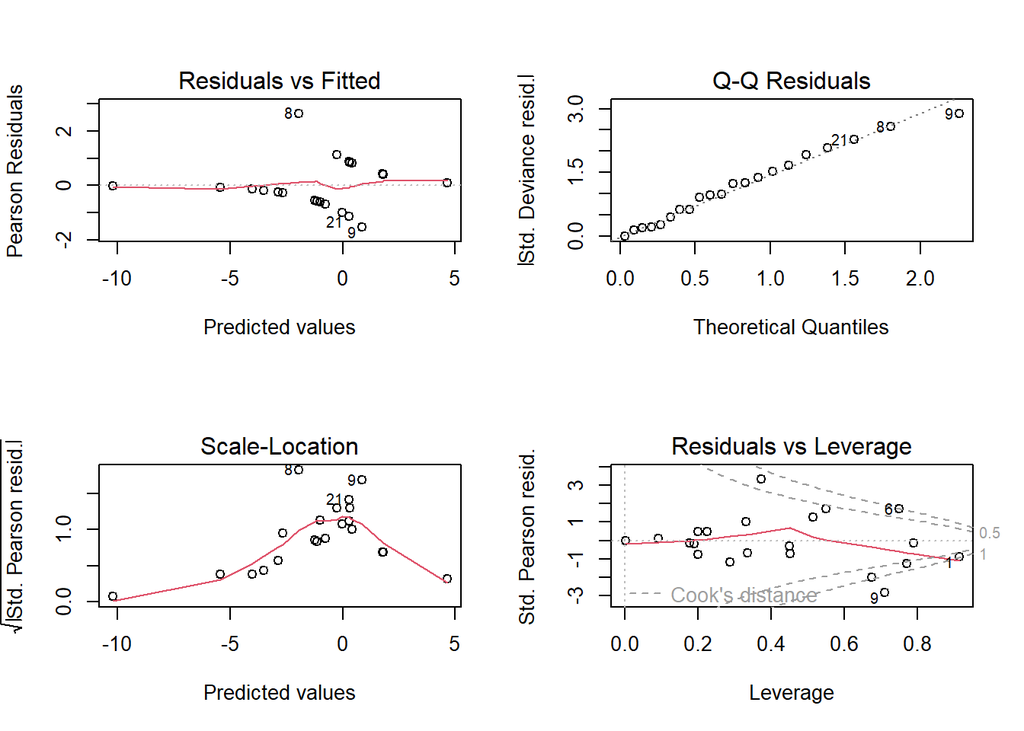

```r
# Assumptions Checking (Diagnostic Plots)
par(mfrow = c(2, 2))  # Set up a 2x2 plot layout
plot(logistic_model)
```

```r
# Plot residuals
plot(resid(logistic_model), ylab = "Residuals")

# Predicting probabilities
predicted_probs <- predict(logistic_model, type = "response")

# Model Accuracy
# Create a confusion matrix
predicted_classes <- ifelse(predicted_probs > 0.5, "High", "Low")
conf_matrix <- table(predicted_classes, combined_data$Feelings_Category)

# Calculate accuracy
accuracy <- sum(diag(conf_matrix)) / sum(conf_matrix)
print(accuracy)
```

```
## [1] 0.1904762
```

```r
# Load required library
library(pROC)
```

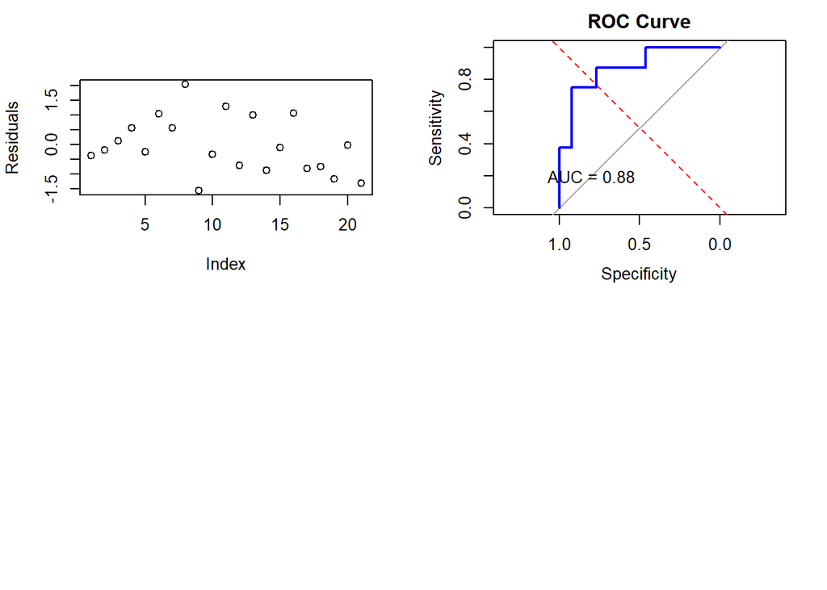

```r
# Calculate ROC curve
roc_curve <- roc(combined_data$Feelings_Category, predicted_probs)
# Plot ROC curve
plot(roc_curve, main = "ROC Curve", col = "blue")

# Add diagonal reference line
abline(a = 0, b = 1, lty = 2, col = "red")

# Add AUC to the plot
auc_value <- auc(roc_curve)
text(0.8, 0.2, paste("AUC =", round(auc_value, 2)), col = "black")
```

The coefficients represent the log odds of the outcome variable (Feelings_Category) for a one-unit increase in each predictor variable.

The p-values associated with each coefficient indicate the statistical significance of the predictors.

Only “Linkedin_Time” has a p-value less than 0.1, suggesting potential significance at the 0.1 significance level.

The null deviance (27.91) represents the deviance when only the intercept is included in the model.

The residual deviance (17.93) represents the deviance after fitting the logistic regression model.

3. LDA:

```r
library(MASS)
library(ggplot2)
library(memisc)
library(ROCR)
str(combined_data)
```

```
## 'data.frame':    21 obs. of  9 variables:
##  $ Instagram_Time   : num  3.5 7.73 3.77 5.38 0 ...
##  $ Linkedin_Time    : num  4 5.2 7 5.317 0.583 ...
##  $ Snapchat_Time    : num  1 3.683 0.533 1.3 0 ...
##  $ Twitter_Time     : num  5 0 0 0 0.667 ...
##  $ Whatsapp_Time    : num  1 4.18 9.83 5.3 3 ...
##  $ Youtube_Time     : num  2.5 4.25 1.85 2 3.5 7 3 2 4 3 ...
##  $ OTT_Time         : num  14.5 0 2 2 2 3 0 3 3 0 ...
##  $ Reddit_Time      : num  2.5 0 0 0 1 0 0 0 0 0 ...
##  $ Feelings_Category: Factor w/ 2 levels "Low","High": 1 1 2 2 1 2 2 2 1 1 ...
```

```r
# See correlation
#Extract independent variables
independent_vars <- combined_data[, -ncol(combined_data)] # Exclude last column (dependent variable)
correlation_matrix <- cor(independent_vars)
print(correlation_matrix)
```

```
##                Instagram_Time Linkedin_Time Snapchat_Time Twitter_Time
## Instagram_Time      1.0000000   0.312136719    0.75664722   -0.2081875
## Linkedin_Time       0.3121367   1.000000000    0.38172781   -0.1300779
## Snapchat_Time       0.7566472   0.381727806    1.00000000   -0.1669074
## Twitter_Time       -0.2081875  -0.130077891   -0.16690740    1.0000000
## Whatsapp_Time       0.5729352   0.262416318    0.40952048   -0.4874131
## Youtube_Time        0.2832555   0.452170173    0.24346648   -0.1882119
## OTT_Time            0.2899576   0.185481917    0.45625980    0.5570731
## Reddit_Time        -0.1278472  -0.007102435   -0.02822626    0.1648546
##                Whatsapp_Time Youtube_Time  OTT_Time  Reddit_Time
## Instagram_Time     0.5729352    0.2832555 0.2899576 -0.127847241
## Linkedin_Time      0.2624163    0.4521702 0.1854819 -0.007102435
## Snapchat_Time      0.4095205    0.2434665 0.4562598 -0.028226256
## Twitter_Time      -0.4874131   -0.1882119 0.5570731  0.164854559
## Whatsapp_Time      1.0000000    0.4178303 0.1515804 -0.126931653
## Youtube_Time       0.4178303    1.0000000 0.1605431  0.026216397
## OTT_Time           0.1515804    0.1605431 1.0000000  0.232735069
## Reddit_Time       -0.1269317    0.0262164 0.2327351  1.000000000
```

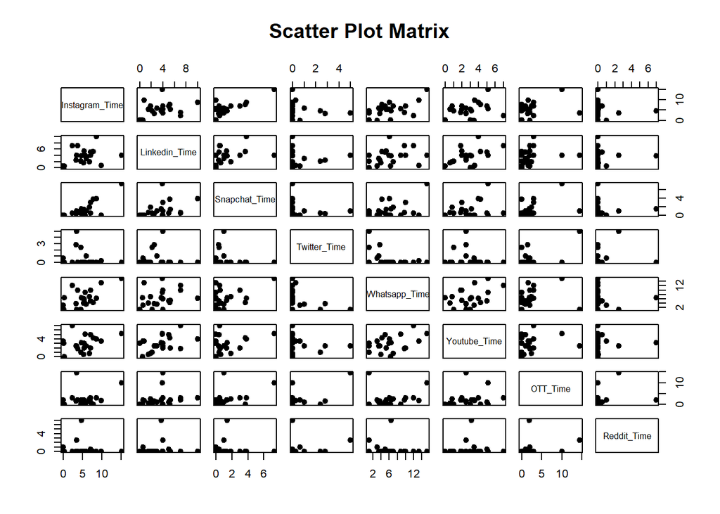

```r
# Create scatter plot matrix
pairs(independent_vars,
       main = "Scatter Plot Matrix", pch = 19) # Set point shape
```

```r
#Based on relvent columns
# Subset the combined_data dataset
subset_data <- combined_data[, c("Instagram_Time", "Linkedin_Time", "Snapchat_Time", "Twitter_Time", "Whatsapp_Time", "Feelings_Category")]

# Print the first few rows of the subsetted data to verify
head(subset_data)
```

```
##   Instagram_Time Linkedin_Time Snapchat_Time Twitter_Time Whatsapp_Time
## 1       3.500000     4.0000000     1.0000000    5.0000000      1.000000
## 2       7.733333     5.2000000     3.6833333    0.0000000      4.183333
## 3       3.766667     7.0000000     0.5333333    0.0000000      9.833333
## 4       5.383333     5.3166667     1.3000000    0.0000000      5.300000
## 5       0.000000     0.5833333     0.0000000    0.6666667      3.000000
## 6       2.333333     7.0000000     0.4666667    0.0000000     12.000000
##   Feelings_Category
## 1               Low
## 2               Low
## 3              High
## 4              High
## 5               Low
## 6              High
```

```r
str(subset_data)
```

```
## 'data.frame':    21 obs. of  6 variables:
##  $ Instagram_Time   : num  3.5 7.73 3.77 5.38 0 ...
##  $ Linkedin_Time    : num  4 5.2 7 5.317 0.583 ...
##  $ Snapchat_Time    : num  1 3.683 0.533 1.3 0 ...
##  $ Twitter_Time     : num  5 0 0 0 0.667 ...
##  $ Whatsapp_Time    : num  1 4.18 9.83 5.3 3 ...
##  $ Feelings_Category: Factor w/ 2 levels "Low","High": 1 1 2 2 1 2 2 2 1 1 ...
```

```r
subset_data_independent <- as.matrix(subset_data[,c(1:5)])
subset_data_raw <- cbind(subset_data_independent, as.numeric(as.factor(subset_data$Feelings_Category))-1)
colnames(subset_data_raw)[6] <- "Feelings_Category"

smp_size_raw <- floor(0.75 * nrow(subset_data_raw))
train_ind_raw <- sample(nrow(subset_data_raw), size = smp_size_raw)
train_raw.df <- as.data.frame(subset_data_raw[train_ind_raw, ])
test_raw.df <- as.data.frame(subset_data_raw[-train_ind_raw, ])

subset_data_raw.lda <- lda(formula = train_raw.df$Feelings_Category ~ ., data = train_raw.df)
subset_data_raw.lda
```

```
## Call:
## lda(train_raw.df$Feelings_Category ~ ., data = train_raw.df)
##
## Prior probabilities of groups:
##   0   1
## 0.6 0.4
##
## Group means:
##   Instagram_Time Linkedin_Time Snapchat_Time Twitter_Time Whatsapp_Time
## 0       6.722222      3.651852     2.0037037    0.9740741      6.951852
## 1       5.516667      4.575000     0.9444444    0.4027778      6.188889
##
## Coefficients of linear discriminants:
##                        LD1
## Instagram_Time  0.03556673
## Linkedin_Time   0.25943993
## Snapchat_Time  -0.46253687
## Twitter_Time   -0.44623568
## Whatsapp_Time  -0.07001705
```

```r
summary(subset_data_raw.lda)
```

```
##         Length Class  Mode
## prior    2     -none- numeric
## counts   2     -none- numeric
## means   10     -none- numeric
## scaling  5     -none- numeric
## lev      2     -none- character
## svd      1     -none- numeric
## N        1     -none- numeric
## call     3     -none- call
## terms    3     terms  call
## xlevels  0     -none- list
```

```r
print(subset_data_raw.lda)
```

```
## Call:
## lda(train_raw.df$Feelings_Category ~ ., data = train_raw.df)
##
## Prior probabilities of groups:
##   0   1
## 0.6 0.4
##
## Group means:
##   Instagram_Time Linkedin_Time Snapchat_Time Twitter_Time Whatsapp_Time
## 0       6.722222      3.651852     2.0037037    0.9740741      6.951852
## 1       5.516667      4.575000     0.9444444    0.4027778      6.188889
##
## Coefficients of linear discriminants:
##                        LD1
## Instagram_Time  0.03556673
## Linkedin_Time   0.25943993
## Snapchat_Time  -0.46253687
## Twitter_Time   -0.44623568
## Whatsapp_Time  -0.07001705
```

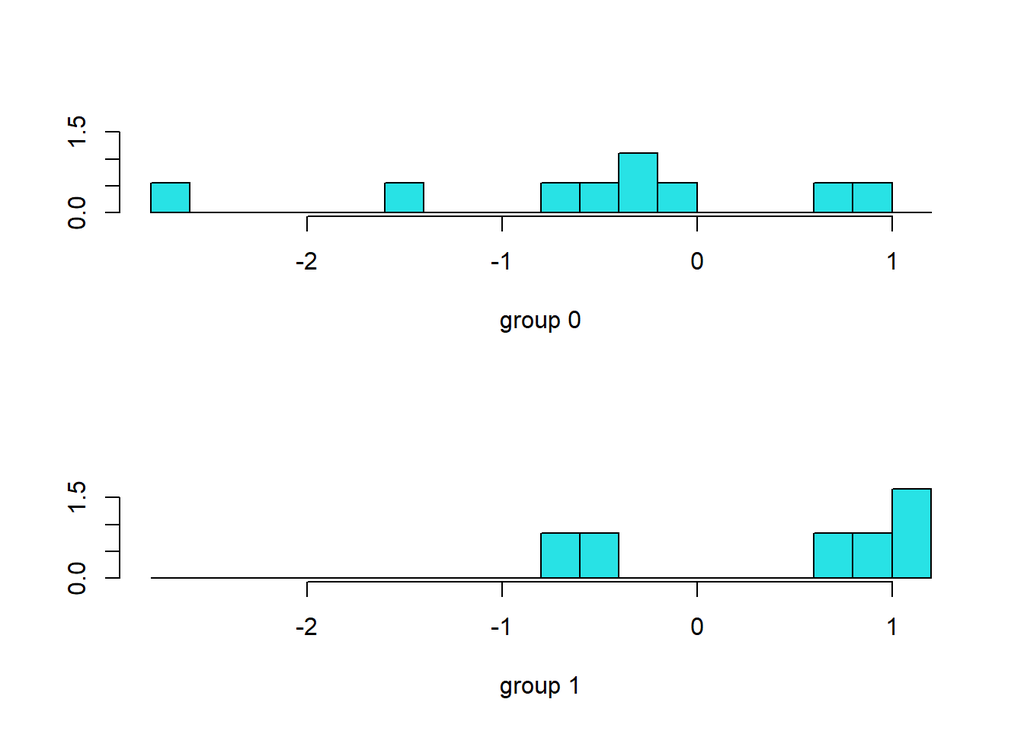

```r
plot(subset_data_raw.lda)
```

```r
subset_data_raw.lda.predict <- predict(subset_data_raw.lda, newdata = test_raw.df)
subset_data_raw.lda.predict$class
```

```
## [1] 1 0 0 0 0 0
## Levels: 0 1
```

```r
subset_data_raw.lda.predict$x
```

```
##            LD1
## 6   1.10672192
## 10  0.19961929
## 13  0.27810428
## 14  0.10743126
## 15  0.29162219
## 21 -0.03373113
```

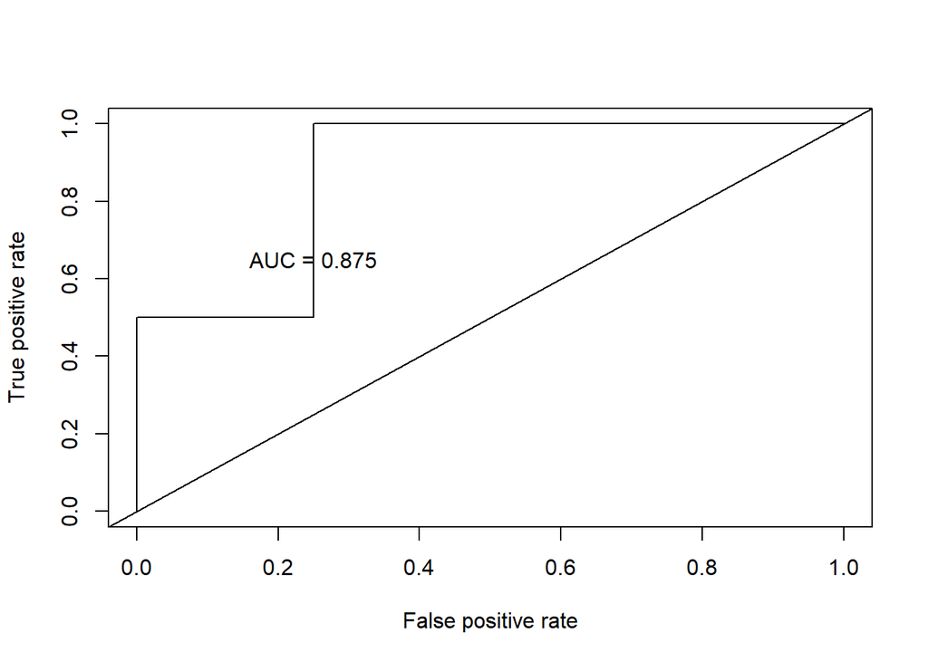

```r
# Get the posteriors as a dataframe.
subset_data_raw.lda.predict.posteriors <- as.data.frame(subset_data_raw.lda.predict$posterior)

pred <- prediction(subset_data_raw.lda.predict.posteriors[,2], test_raw.df$Feelings_Category)
roc.perf = performance(pred, measure = "tpr", x.measure = "fpr")
auc.train <- performance(pred, measure = "auc")
auc.train <- auc.train@y.values
plot(roc.perf)
abline(a=0, b= 1)
text(x = .25, y = .65 ,paste("AUC = ", round(auc.train[[1]],3), sep = ""))
```

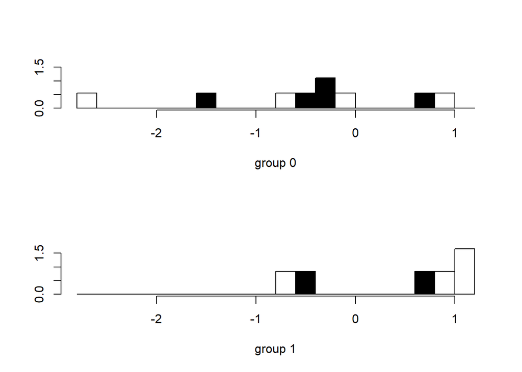

```r
# do a quick plot to understand how good the model is
plot(subset_data_raw.lda, col = as.integer(train_raw.df$Feelings_Category))
```

```r
# Sometime bell curves are better
#plot(subset_data_raw.lda, dimen = 1, type = "b")
# THis plot shows the essense of LDA. It puts everything on a line and finds cutoffs.
# Partition plots
#partimat(Species ~ Weigth + Sepal.Width + Length1 + Length2 + Length3 + Height + Width, data=train_raw.df_new, method="lda")

# Lets focus on accuracy. Table function
lda.train <- predict(subset_data_raw.lda)
train_raw.df$lda <- lda.train$class
table(train_raw.df$lda,train_raw.df$Feelings_Category)
```

```
##
##     0 1
##   0 7 2
##   1 2 4
```

```r
# running accuracy on the training set shows how good the model is. It is not an indication of "true" accuracy. We will use the test set to approximate accuracy
lda.test <- predict(subset_data_raw.lda,test_raw.df)
test_raw.df$lda <- lda.test$class
table(test_raw.df$lda,test_raw.df$Feelings_Category)
```

```
##
##     0 1
##   0 4 1
##   1 0 1
```

Some variables have moderate to strong correlations with each other, which may indicate multicollinearity. For example, “Instagram_Time” and “Snapchat_Time” have a correlation coefficient of 0.76.

#Learning and Takeaways

PCA may reveal insights into how different social media platforms are used by students, which platforms are correlated, and which have the most significant impact on overall usage patterns.

FA can address multicollinearity issues in social media data by extracting common variance shared among variables into latent factors, which can improve the stability and interpretability of subsequent analyses.

Analyzing clusters can provide insights into the characteristics and dynamics of each user group, such as common interests, engagement levels, or responses to content, facilitating data-driven decision-making in social media management.

LM coefficients can help identify which social media platforms or usage behaviors have a significant impact on students’ weekly feelings or other outcomes, guiding interventions or recommendations for healthier social media habits.

Checking LDA assumptions (e.g., normality, equal covariance matrices) ensures the reliability of the classification results and the interpretability of discriminant functions, guiding the appropriate use of LDA in social media analysis.